# Machine Learning II - Group D - MBD16 - Competition

# Instructions

Calling below function after running the RMD file will output a Data Frame with the ‘id’ variable and the prediction for ‘status_group’ including a header for the test dataset that lays on the filepath.

`evaluate('filepath')`

# Table of content

1. Data Exploration
2. Feature Engineering
3. Feature Selection
4. Model Selection

# 1. Data Exploration

Before starting engineering the features, the dataset is explored by plotting relevant features.

```
FALSE status_group
FALSE              functional functional needs repair          non functional
FALSE                   29034                    3926                   20500
FALSE status_group
FALSE              functional functional needs repair          non functional
FALSE              0.54309764              0.07343808              0.38346427
```

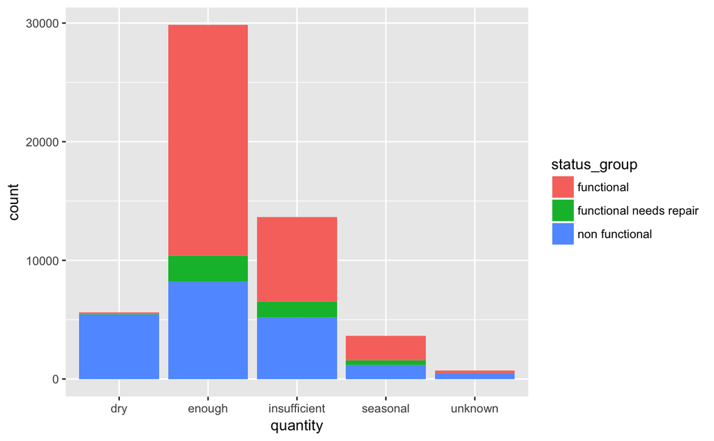

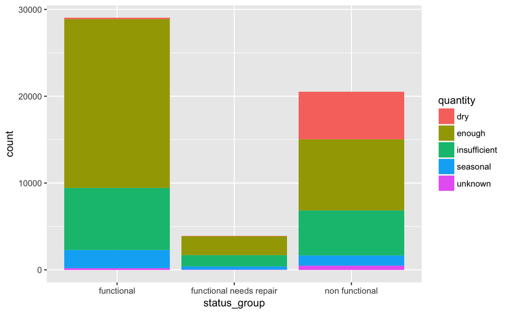

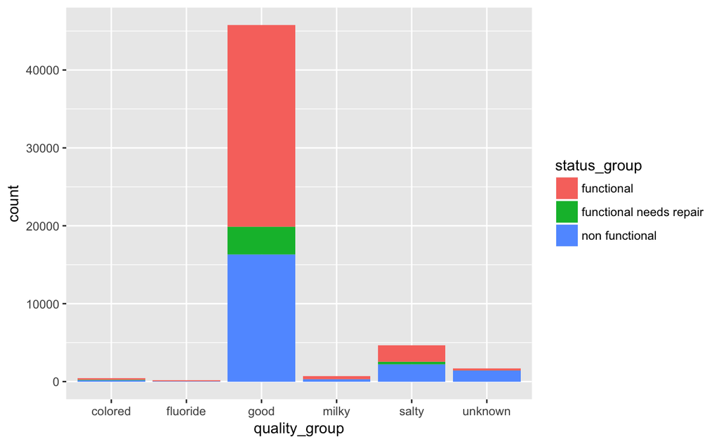

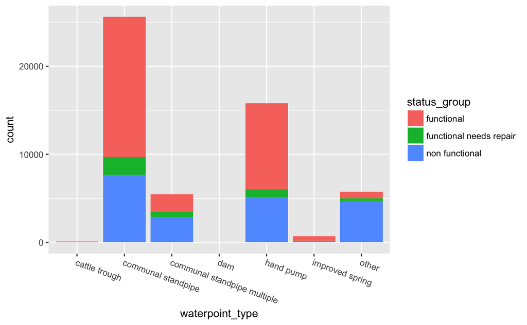

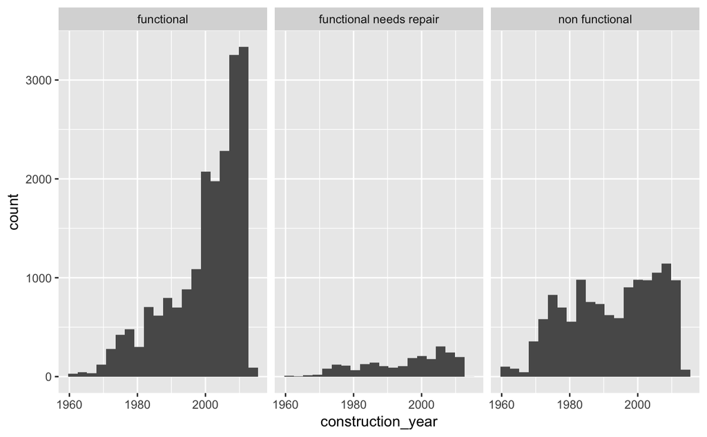

[figure not shown]

Above visualizations help choose relevant features that are possible strong predictors.

# 2. Feature Engineering

An additional feature which represents the number of days since the data was obtained, is created.

Reducing factor levels for categorical variables ‘installer’ and ‘funder’. Same values with different name variations are combined to a single level. Rare levels are combined into a single level ‘Others’.

```r
# Converting date to datetime class
finalWP$date_recorded <- as.Date(finalWP$date_recorded)
# Creating new feature from recorded date
finalWP$days_since_last_recorded <- max(finalWP$date_recorded)-finalWP$date_recorded
finalWP$days_since_last_recorded <- as.integer(finalWP$days_since_last_recorded)
# Selecting features with missing values for imputation
impWP <- select(finalWP,id,population,construction_year)
impWP$population[impWP$population == 0] <- NA
impWP$construction_year[impWP$construction_year == 0]<- NA
# Performing mice imputation, based on random forests
# miceMod <- mice(impWP[, !names(impWP) %in% "id"], method="rf")
```

```r
finalWP$gps_height <- as.numeric(height$gps_height[,1])
```

[output not shown]

# 3. Feature Selection

Unneccesary, non-interpretable, constant or unclear features are removed. Feature importance and selection will be handled by random forest in the modeling section.

```r
# Removing redundant features
finalWP <- finalWP[, -which(names(finalWP) == "recorded_by")] # only one value (organization which recorded the information)
finalWP <- finalWP[, -which(names(finalWP) == "quantity_group")] # same as quantity
finalWP <- finalWP[, -which(names(finalWP) == "region_code")] # code for region
finalWP <- finalWP[, -which(names(finalWP) == "date_recorded")] # Date row was entered (not a factor determining functionality)
finalWP <- finalWP[, -which(names(finalWP) == "num_private")] #undefined,id field
finalWP <- finalWP[, -which(names(finalWP) == "district_code")]
finalWP <- finalWP[, -which(names(finalWP) == "quality_group")] #identical to water_quality
finalWP <- finalWP[, -which(names(finalWP) == "payment_type")] # similar to payment
finalWP <- finalWP[, -which(names(finalWP) == "scheme_management")] #similar to management
finalWP <- finalWP[, -which(names(finalWP) == "management_group")] #similar to management
finalWP <- finalWP[, -which(names(finalWP) == "source")] #similiar to source_type
finalWP <- finalWP[, -which(names(finalWP) == "subvillage")] #too many levels
finalWP <- finalWP[, -which(names(finalWP) == "wpt_name")] #too many levels
finalWP <- finalWP[, -which(names(finalWP) == "ward")]
finalWP <- finalWP[, -which(names(finalWP) == "lga")]
finalWP <- finalWP[, -which(names(finalWP) == "scheme_name")]
finalWP <- finalWP[, -which(names(finalWP) == "extraction_type")]
finalWP <- finalWP[, -which(names(finalWP) == "extraction_type_group")]
finalWP <- finalWP[, -which(names(finalWP) == "waterpoint_type_group")]
finalWP <- finalWP[, -which(names(finalWP) == "amount_tsh")]
```

# 4. Modeling Section

Using tuneRF function the optimal value ‘mtry = 4’ to use in a random forest algorithm is computed.

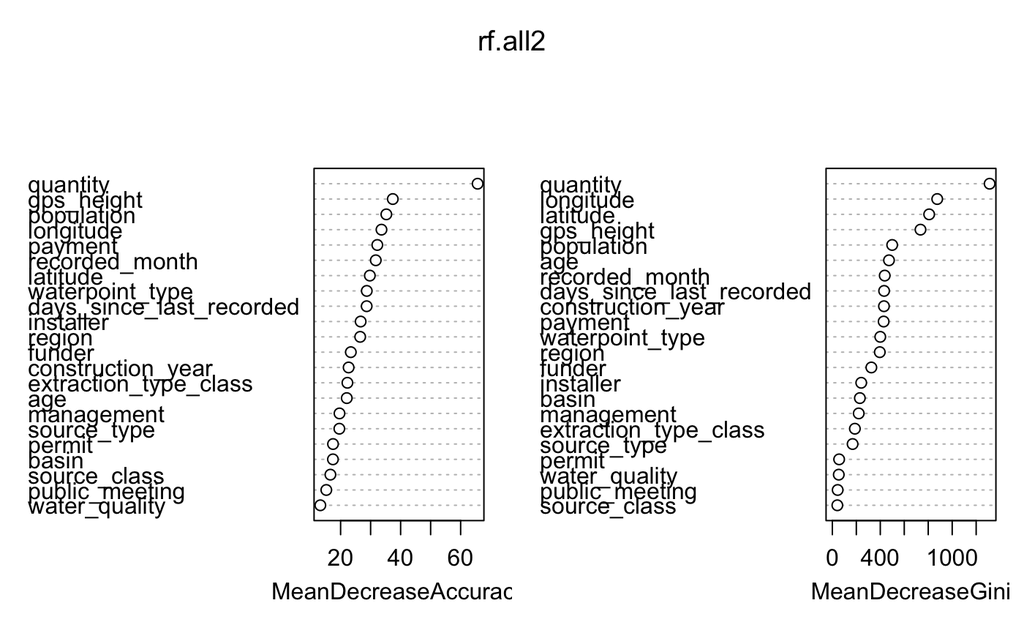

```r
# train/test split
set.seed(1234)
sample <- sample.split(finalWP$status_group, SplitRatio = .7)
train <- subset(finalWP, sample == TRUE)
test <- subset(finalWP, sample == FALSE)
# Commented for notebook efficiency:
# Tuning Randomforest for optimal mtry parameter
#rf.all.tune <- tuneRF(finalWP[,-19], finalWP[,19], ntreeTry=800, stepFactor=1.5)
# Randomforest 2
set.seed(12345)
rf.all2 <- randomForest(status_group ~ .-id, mtry=4,ntree = 100,data=train,importance=TRUE)
varImpPlot(rf.all2)
```

```r
yhat.rf2 <- predict(rf.all2 ,newdata=test,type = "response")
confusionMatrix(test$status_group,yhat.rf2)
```

```
Confusion Matrix and Statistics

                         Reference
Prediction                functional functional needs repair non functional
  functional                    3916                     106            299
  functional needs repair        289                     177             85
  non functional                 477                      38           2102

Overall Statistics

               Accuracy : 0.8272
                 95% CI : (0.8185, 0.8357)
    No Information Rate : 0.6252
    P-Value [Acc > NIR] : < 2.2e-16

                  Kappa : 0.6678
 Mcnemar's Test P-Value : < 2.2e-16

Statistics by Class:

                     Class: functional Class: functional needs repair Class: non functional
Sensitivity                     0.8364                        0.55140                0.8455
Specificity                     0.8557                        0.94782                0.8971
Pos Pred Value                  0.9063                        0.32123                0.8032
Neg Pred Value                  0.7582                        0.97924                0.9212
Prevalence                      0.6252                        0.04286                0.3320
Detection Rate                  0.5229                        0.02363                0.2807
Detection Prevalence            0.5770                        0.07357                0.3494
Balanced Accuracy               0.8461                        0.74961                0.8713
```